# Week 8 Tutorials: Spatial and Dynamic Networks - Solutions

161.307 Reproducible Visualisation for Statistics

## Overview

1. **Tutorial 1 (45–50 min)** - Networks on maps
2. **Tutorial 2 (45–50 min)** - Visualising change over time
3. **Tutorial 3 (double)** - Capstone: simulated spread on a network, with uncertainty and space

```r
library(tidygraph)
library(ggraph)
library(ggplot2)
library(dplyr)
library(sf)
library(patchwork)
library(igraph)
library(rnaturalearth) # NZ basemap for Exercise 1.1
# Regional (admin-1) boundaries additionally need rnaturalearthhires:
# install.packages("rnaturalearthhires", repos = "https://ropensci.r-universe.dev")
```

## Tutorial 1: Networks on maps

### 1.1 A spatial network dataset

```r
cities <- data.frame(
  name = c("Auckland", "Wellington", "Christchurch", "Hamilton",
           "Dunedin", "Tauranga", "Palmerston North"),
  lon  = c(174.76, 174.78, 172.64, 175.28, 170.50, 176.17, 175.61),
  lat  = c(-36.85, -41.29, -43.53, -37.78, -45.87, -37.69, -40.36),
  population = c(1657000, 215100, 396700, 184900, 134600, 158300, 89300)
)

edges <- data.frame(
  from = c("Auckland","Auckland","Hamilton","Wellington","Wellington","Tauranga"),
  to   = c("Wellington","Hamilton","Tauranga","Christchurch","Palmerston North","Christchurch")
)

g <- tbl_graph(nodes = cities, edges = edges, directed = FALSE)
```

### 1.2 Plotting with manual layout

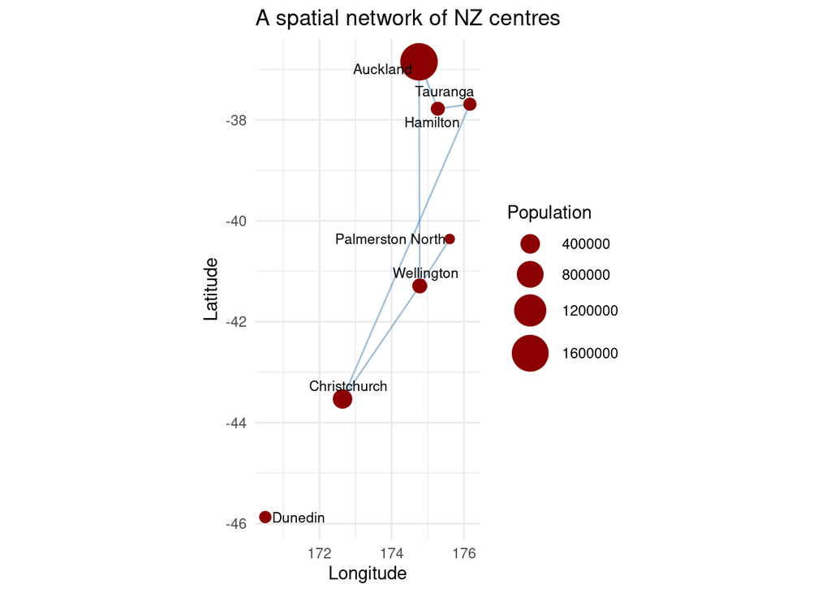

```r
ggraph(g, layout = "manual", x = cities$lon, y = cities$lat) +
  geom_edge_link(alpha = 0.5, colour = "steelblue") +
  geom_node_point(aes(size = population), colour = "darkred") +
  geom_node_text(aes(label = name), repel = TRUE, size = 3) +
  scale_size_area(max_size = 10) +
  coord_fixed(ratio = 1.4) +
  theme_minimal() +
  labs(title = "A spatial network of NZ centres",
       x = "Longitude", y = "Latitude", size = "Population")
```

> **Exercise 1.1** - Find an `sf` polygon dataset of NZ regions (e.g. `rnaturalearth`, or one reused from the choropleth weeks). Plot it with `geom_sf()` as a background layer, then overlay the network from above. Check the CRS of both layers (`st_crs()`). If they differ, use `st_transform()` so they align.

**Solution.** If an NZ regions `sf` object already exists from an earlier week, reuse it directly and skip straight to the CRS check below. Otherwise, `rnaturalearth` is the natural source (see the package’s [intro vignette](https://docs.ropensci.org/rnaturalearth/articles/rnaturalearth.html)):

```r
library(rnaturalearth)

cities_sf <- st_as_sf(cities, coords = c("lon", "lat"), crs = 4326)

# rnaturalearth's regional (admin-1) boundaries, ne_states(), are
# distributed at 10m resolution via the separate `rnaturalearthhires`
# package, which lives on the ropensci r-universe rather than CRAN:
#   install.packages("rnaturalearthhires",
#                     repos = "https://ropensci.r-universe.dev")
# Country-level outlines (ne_countries()) don't need it and work
# straight out of the box.
regions_sf <- tryCatch(
  {
    if (!requireNamespace("rnaturalearthhires", quietly = TRUE)) {
      stop("rnaturalearthhires not installed")
    }
    ne_states(country = "New Zealand", returnclass = "sf") |>
      select(name, geometry) |>
      # attach the city population nearest each region, just so we have
      # *something* to map as a fill colour. Feel free to swap for a real regional
      # variable (e.g. regional population, from Stats NZ) if you have one
      st_join(cities_sf["population"], join = st_nearest_feature) |>
      mutate(region_value = population / 1000)
  },
  error = function(e) {
    message("Falling back to country outline only: ", conditionMessage(e))
    ne_countries(country = "New Zealand", scale = "medium", returnclass = "sf") |>
      mutate(region_value = NA_real_)
  }
)

# Build edge lines from the (lon, lat) coordinates
edge_lines <- lapply(seq_len(nrow(edges)), function(i) {
  from_pt <- as.numeric(cities[cities$name == edges$from[i], c("lon", "lat")])
  to_pt   <- as.numeric(cities[cities$name == edges$to[i],   c("lon", "lat")])
  st_linestring(rbind(from_pt, to_pt))
})
edges_sf <- st_sf(edges, geometry = st_sfc(edge_lines, crs = 4326))

# CRS check
st_crs(cities_sf)$input
```

```
[1] "EPSG:4326"
```

```r
st_crs(regions_sf)$input
```

```
[1] "WGS 84"
```

```r
st_crs(edges_sf)$input
```

```
[1] "EPSG:4326"
```

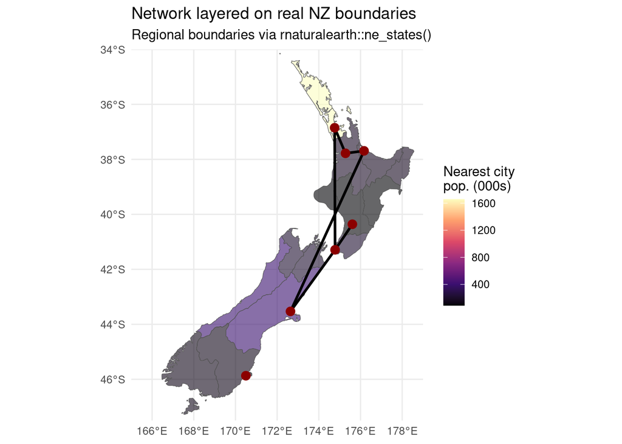

```r
# All three report EPSG:4326 here, so no st_transform() is needed.
# If your real regions layer comes in NZTM (EPSG:2193) instead, transform
# the other layers to match, e.g.:
# regions_sf <- st_transform(regions_sf, 2193)
# cities_sf <- st_transform(cities_sf,  st_crs(regions_sf))
# edges_sf <- st_transform(edges_sf,   st_crs(regions_sf))

have_regions <- !all(is.na(regions_sf$region_value))

ggplot() +
  geom_sf(data = regions_sf, aes(fill = region_value), alpha = 0.6) +
  geom_sf(data = edges_sf, colour = "black", linewidth = 1) +
  geom_sf(data = cities_sf, colour = "darkred", size = 3) +
  scale_fill_viridis_c(option = "magma", name = "Nearest city\npop. (000s)", na.value = "grey90") +
  # Zoom to mainland NZ. Without this, coord_sf() defaults to the
  # bounding box of the data and Natural Earth's NZ polygon includes
  # outlying islands (e.g. the Chathams) on the far side of the +/-180
  # meridian. A naive bbox across the dateline spans nearly the whole
  # globe "the long way round", shrinking the country to a speck in the
  # corner of a near-world map
  coord_sf(xlim = c(165, 179), ylim = c(-47.5, -34), expand = FALSE) +
  theme_minimal() +
  labs(
    title = "Network layered on real NZ boundaries",
    subtitle = if (have_regions) {
      "Regional boundaries via rnaturalearth::ne_states()"
    } else {
      "Country outline only -- rnaturalearthhires not installed"
    }
  )
```

The key habit, regardless of which polygon layer you use: **check `st_crs()` on every layer before plotting**, and `st_transform()` anything that doesn’t match. A silent CRS mismatch typically does not output an error. It just quietly misaligns the layers, which is exactly why it’s worth checking explicitly rather than trusting that “it looks about right”. A second, NZ-specific habit worth flagging: **check the plotted extent, too**, not just the CRS. A country whose territory straddles the ±180° meridian (NZ, Fiji, Russia…) can silently blow up `coord_sf()`’s auto-computed bounding box to nearly the whole globe. The fix is the same idea as an axis-limit check in any other plot: look at what range actually got drawn, and set `coord_sf(xlim=, ylim=)` explicitly if it is wrong.

### 1.3 Edge width as flow strength

> **Exercise 1.2** - Add an edge attribute (e.g. invent a “flow” value, or compute one as `pmin(population[from], population[to])`), and map it to `geom_edge_link(aes(width = flow))`. Use `scale_edge_width()` to control the range. Discuss: at what point would this network have too many edges for width-encoding to remain readable, and what would you do instead (refer back to Week 7’s hairball discussion)?

**Solution.** `population` as originally created is a plain numeric vector with no names, so indexing it by city name (`population[from]`) would silently return `NA` for every edge. Give it names first so the lookup works:

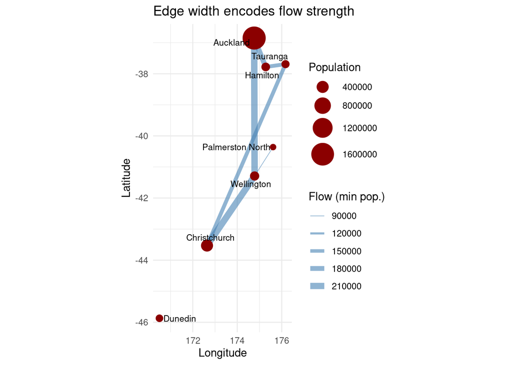

```r
population <- setNames(cities$population, cities$name)

edges <- edges |>
  mutate(flow = pmin(population[from], population[to]))

g <- tbl_graph(nodes = cities, edges = edges, directed = FALSE)

ggraph(g, layout = "manual", x = cities$lon, y = cities$lat) +
  geom_edge_link(aes(width = flow), alpha = 0.6, colour = "steelblue") +
  geom_node_point(aes(size = population), colour = "darkred") +
  geom_node_text(aes(label = name), repel = TRUE, size = 3) +
  scale_edge_width(range = c(0.3, 3), name = "Flow (min pop.)") +
  scale_size_area(max_size = 10) +
  coord_fixed(ratio = 1.4) +
  theme_minimal() +
  labs(title = "Edge width encodes flow strength",
       x = "Longitude", y = "Latitude", size = "Population")
```

**Discussion.** Width-encoding degrades the same way it does off a map: once there are more than roughly a dozen or two overlapping edges in the same region, individual widths become impossible to compare by eye, and crossing lines of different widths start to visually merge. On a map specifically, this tends to happen *locally*, when a handful of large cities generate lots of short, overlapping edges. This occurs even when the overall edge count is modest. At that point, the fixes from Week 7’s hairball discussion still apply, with a spatial twist:

- **Edge bundling** (e.g. the `edgebundle` package) groups routes that travel similar paths, which is often more effective on a map than off one because real-world edges (flights, commutes) genuinely do share physical corridors.
- **Overlap-as-density**: many low-alpha edges (`geom_edge_fan`, as in Lecture 1) so that shared corridors darken through overlap while a single trip stays nearly invisible.
- **Aggregate to a matrix or flow map** (e.g. total flow per region-pair, or an alluvial-style view) rather than drawing every individual edge.

## Tutorial 2: Visualising change over time

### 2.1 A network that grows over time

```r
nodes <- data.frame(name = LETTERS[1:8])

all_edges <- data.frame(
  from = c("A","A","B","C","D","A","E","F","G","B"),
  to   = c("B","C","C","D","E","F","F","G","H","H"),
  time = c(1,1,1,2,2,2,3,3,3,4)
)
```

### 2.2 Small multiples (snapshots)

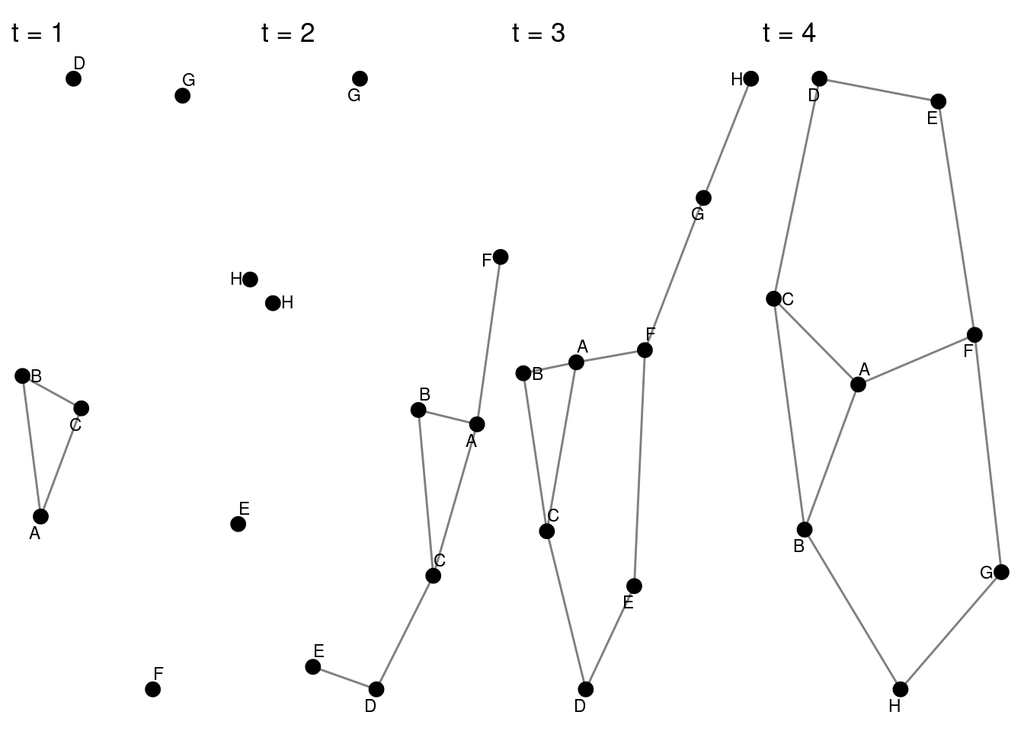

```r
make_snapshot <- function(t) {
  edges_t <- all_edges |> filter(time <= t)
  g_t <- tbl_graph(nodes = nodes, edges = edges_t, directed = FALSE)
  ggraph(g_t, layout = "fr") +
    geom_edge_link(alpha = 0.5) +
    geom_node_point(size = 3) +
    geom_node_text(aes(label = name), repel = TRUE, size = 3) +
    theme_void() +
    labs(title = paste("t =", t))
}

# NOTE: each call to ggraph(layout = "fr") re-runs the layout algorithm,
# so node positions may move between panels. See Exercise 2.1.
wrap_plots(lapply(1:4, make_snapshot), nrow = 1)
```

> **Exercise 2.1** - The snapshots above (likely) show nodes “jumping around” between panels, because each panel recomputes its own force-directed layout. Fix this by computing **one** layout using the *final* (most complete) network, extracting node coordinates (`create_layout()`), and reusing those fixed coordinates (`layout = "manual", x = ..., y = ...`) for every snapshot. Regenerate the small multiples. How does this change your interpretation of “network growth” across panels?

**Solution.**

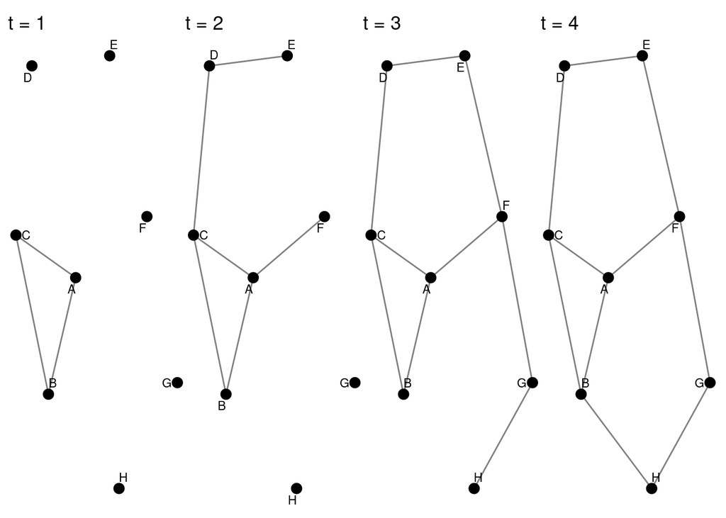

```r
g_final <- tbl_graph(nodes = nodes, edges = all_edges, directed = FALSE)
lay_final <- create_layout(g_final, layout = "fr")

make_snapshot_fixed <- function(t) {
  edges_t <- all_edges |> filter(time <= t)
  g_t <- tbl_graph(nodes = nodes, edges = edges_t, directed = FALSE)
  ggraph(g_t, layout = "manual", x = lay_final$x, y = lay_final$y) +
    geom_edge_link(alpha = 0.5) +
    geom_node_point(size = 3) +
    geom_node_text(aes(label = name), repel = TRUE, size = 3) +
    theme_void() +
    labs(title = paste("t =", t))
}

wrap_plots(lapply(1:4, make_snapshot_fixed), nrow = 1)
```

**Interpretation.** With a fixed layout, every node occupies the *same* position in every panel, so any change you see between panels is purely edges being added. There is no confound from the layout algorithm finding a different arrangement each time. This is the network analogue of holding the axis scales constant across small multiples: without it, you can’t tell whether the network “grew” or the picture just rearranged itself. The trade-off is that a layout chosen for the *final* network may not be the most legible layout for an early, sparse snapshot — but that’s a small price for a valid comparison.

### 2.3 Animation (optional)

> **Exercise 2.2 (optional)** - If `gganimate` is available, animate the snapshots from 2.2 (fixed layout) as a `transition_states()` animation. Compare the animated version to the small-multiples version: which makes it easier to (a) see the *final* network structure, (b) see *when* a particular edge was added? Relate this back to the Week 5 spaghetti-vs-small-multiples discussion. What’s the temporal analogue of “overplotting” here?

**Solution.**

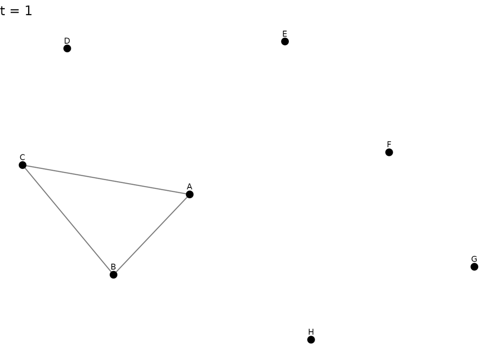

```r
library(gganimate)

# Build one long-format node table, replicated per frame, with a
# cumulative edge list per frame
edges_growth <- lapply(1:4, function(t) {
  all_edges |> filter(time <= t) |> mutate(frame = t)
}) |> bind_rows()

anim_plot <- ggraph(g_final, layout = "manual", x = lay_final$x, y = lay_final$y) +
  geom_node_point(size = 3) +
  geom_node_text(aes(label = name), repel = TRUE, size = 3) +
  theme_void()

# gganimate needs the edges as the animated layer; the simplest robust
# approach is to pre-render one ggraph per frame (as in make_snapshot_fixed)
# and stitch with magick, OR build a single long-format edge data frame
# and use transition_states() directly with geom_segment():
edges_xy <- edges_growth |>
  left_join(as.data.frame(lay_final)[, c("name", "x", "y")], by = c("from" = "name")) |>
  rename(x_from = x, y_from = y) |>
  left_join(as.data.frame(lay_final)[, c("name", "x", "y")], by = c("to" = "name")) |>
  rename(x_to = x, y_to = y)

nodes_xy <- as.data.frame(lay_final)[, c("name", "x", "y")]

p_anim <- ggplot() +
  geom_segment(data = edges_xy, aes(x = x_from, y = y_from, xend = x_to, yend = y_to),
               alpha = 0.5) +
  geom_point(data = nodes_xy, aes(x, y), size = 3) +
  geom_text(data = nodes_xy, aes(x, y, label = name), nudge_y = 0.1, size = 3) +
  theme_void() +
  transition_states(frame, transition_length = 1, state_length = 1) +
  labs(title = "t = {closest_state}")

# See the troubleshooting note in Tutorial 3's animation chunk if you hit
# "Error in `device()`: unable to start device 'png'" (I didn't have the issue here,
# but made it uniform)
anim_device <- if (requireNamespace("ragg", quietly = TRUE)) "ragg_png" else "png"
animate(p_anim, nframes = 60, fps = 10, renderer = gifski_renderer(), device = anim_device)
```

**Discussion.** Small multiples make the *final* structure and the overall shape of growth easy to compare at a glance (all panels visible simultaneously, easy to scan back and forth). Animation is better at conveying *when* a specific edge appeared, because the viewer sees each addition as a discrete event in time rather than having to spot a difference between two static panels. But it is transient: once the animation has played, you cannot re-inspect an earlier frame without replaying it, and it is not reproducible as a single static figure for a report.

The temporal analogue of overplotting here is **too many changes per transition**: just as a spaghetti plot overwhelms the reader with too many overlapping *lines* at once, an animation with many edges appearing in the same frame-to-frame jump (or transitions that are too fast) overwhelms the reader’s ability to track *what just changed*. The fix is the same in spirit as Week 5’s: slow down / space out the “reveals” (smaller time steps, more frames), or fall back to small multiples when there’s too much change to track in real time.

## Tutorial 3 (double session): Capstone on simulated spread with uncertainty

### Short session: A simple epidemic-on-network simulation

```r
set.seed(1)

n_nodes <- 30
g_sim <- play_erdos_renyi(n_nodes, p = 0.08, directed = FALSE) |>
  mutate(name = as.character(1:n_nodes))

adj <- as.matrix(igraph::as_adjacency_matrix(g_sim))

simulate_sir <- function(adj, p_infect = 0.15, p_recover = 0.1,
                          n_steps = 30, seed) {
  set.seed(seed)
  n <- nrow(adj)
  status <- rep("S", n)
  status[sample(1:n, 1)] <- "I"

  history <- matrix(NA_character_, nrow = n_steps, ncol = n)
  history[1, ] <- status

  for (t in 2:n_steps) {
    infected <- which(status == "I")
    susceptible <- which(status == "S")

    new_infections <- c()
    for (s in susceptible) {
      neighbours <- which(adj[s, ] == 1)
      n_infected_neighbours <- sum(neighbours %in% infected)
      if (n_infected_neighbours > 0) {
        prob_escape <- (1 - p_infect)^n_infected_neighbours
        if (runif(1) > prob_escape) new_infections <- c(new_infections, s)
      }
    }

    recoveries <- infected[runif(length(infected)) < p_recover]

    status[new_infections] <- "I"
    status[recoveries] <- "R"
    history[t, ] <- status
  }

  history
}

hist1 <- simulate_sir(adj, seed = 1)
```

> **Exercise 3.1** - Compute, for `hist1`, the number of S/I/R individuals at each time step (e.g. `apply(hist1, 1, table)`). Plot these three counts over time as a simple line plot (three lines, one per compartment). This is the “compartment trajectory” idiom from Lecture 2, and structurally identical to a Week 5 single-realisation plot.

**Solution.**

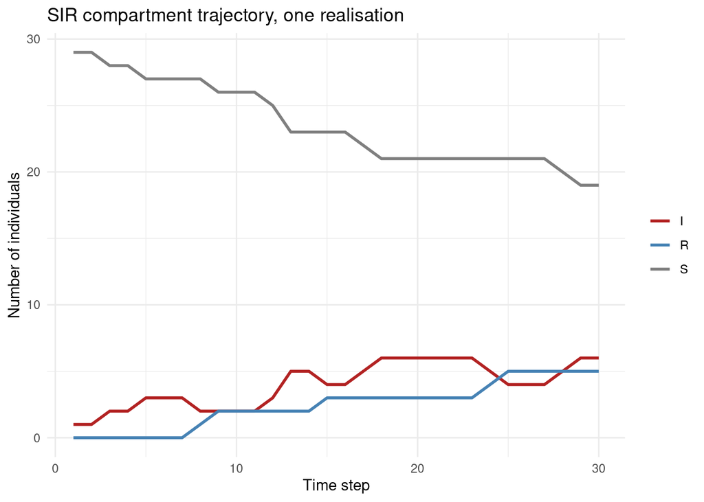

```r
counts_df <- data.frame(
  time = 1:nrow(hist1),
  S = rowSums(hist1 == "S"),
  I = rowSums(hist1 == "I"),
  R = rowSums(hist1 == "R")
) |>
  tidyr::pivot_longer(cols = c(S, I, R), names_to = "compartment", values_to = "count")

ggplot(counts_df, aes(time, count, colour = compartment)) +
  geom_line(linewidth = 1) +
  scale_colour_manual(values = c(S = "grey50", I = "firebrick", R = "steelblue")) +
  labs(title = "SIR compartment trajectory, one realisation",
       x = "Time step", y = "Number of individuals", colour = NULL) +
  theme_minimal()
```

### Long session (after break)

#### Panel A: Network snapshot

> **Exercise 3.2** - Choose a time point `t` partway through the epidemic (e.g. where I is near its peak in `hist1`). Build a `tbl_graph` from `g_sim`, add a `status` node attribute from `hist1[t, ]`, and plot with `geom_node_point(aes(colour = status))` using a clear S/I/R colour scheme (e.g. grey/red/blue). This is Panel A of your capstone figure.

**Solution.**

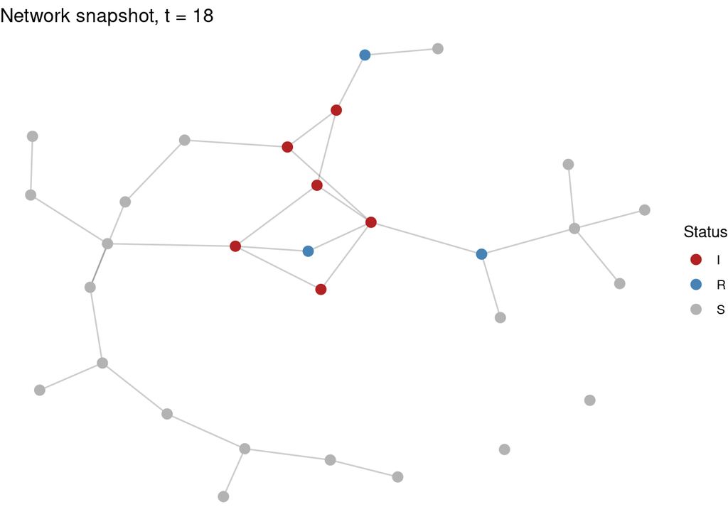

```r
t_peak <- which.max(rowSums(hist1 == "I"))

g_snapshot <- g_sim |>
  activate(nodes) |>
  mutate(status = hist1[t_peak, ])

lay_sim <- create_layout(g_snapshot, layout = "fr")

panel_A <- ggraph(g_snapshot, layout = "manual", x = lay_sim$x, y = lay_sim$y) +
  geom_edge_link(alpha = 0.2) +
  geom_node_point(aes(colour = status), size = 3) +
  scale_colour_manual(values = c(S = "grey70", I = "firebrick", R = "steelblue")) +
  theme_void() +
  labs(title = paste("Network snapshot, t =", t_peak), colour = "Status")

panel_A
```

#### Panel B: Multiple runs with uncertainty ribbon

```r
n_sims <- 100
n_steps <- 30

results <- lapply(1:n_sims, function(i) {
  h <- simulate_sir(adj, seed = i, n_steps = n_steps)
  data.frame(
    sim = i,
    time = 1:n_steps,
    n_infected = rowSums(h == "I")
  )
})
results <- bind_rows(results)
```

> **Exercise 3.3** - Using `results`, build a ribbon plot of `n_infected` over time (median + 50%/90% bands across the 100 simulations). This is *exactly* the Week 5/6 ribbon code, applied to a new variable. This is Panel B of your capstone figure.

**Solution.**

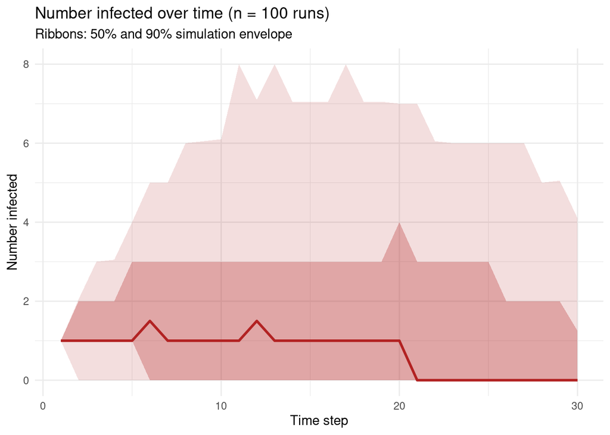

```r
ribbon_df <- results |>
  group_by(time) |>
  summarise(
    median_I = median(n_infected),
    lo50 = quantile(n_infected, 0.25),
    hi50 = quantile(n_infected, 0.75),
    lo90 = quantile(n_infected, 0.05),
    hi90 = quantile(n_infected, 0.95)
  )

panel_B <- ggplot(ribbon_df, aes(time, median_I)) +
  geom_ribbon(aes(ymin = lo90, ymax = hi90), alpha = 0.15, fill = "firebrick") +
  geom_ribbon(aes(ymin = lo50, ymax = hi50), alpha = 0.3, fill = "firebrick") +
  geom_line(colour = "firebrick", linewidth = 1) +
  labs(title = paste0("Number infected over time (n = ", n_sims, " runs)"),
       subtitle = "Ribbons: 50% and 90% simulation envelope",
       x = "Time step", y = "Number infected") +
  theme_minimal()

panel_B
```

#### Panel C: Spatial view (optional, if coordinates available)

> **Exercise 3.4 (optional)** - If you have or can assign coordinates to the 30 nodes (we will use random points within a region, but use real locations if relevant to your data), reuse Tutorial 1’s `layout = "manual"` approach to plot Panel A’s network snapshot on a map instead of an abstract layout.

**Solution.**

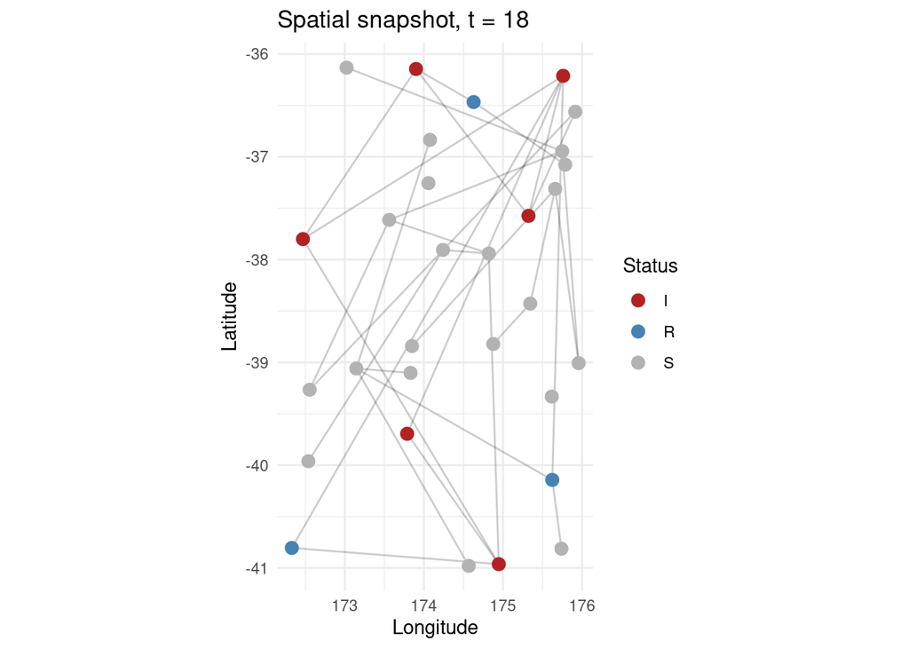

```r
set.seed(42)
sim_coords <- data.frame(
  name = as.character(1:n_nodes),
  lon = runif(n_nodes, 172, 176),
  lat = runif(n_nodes, -41, -36)
)

g_snapshot_spatial <- g_snapshot |>
  activate(nodes) |>
  left_join(sim_coords, by = "name")

nodes_df <- g_snapshot_spatial |> activate(nodes) |> as_tibble()

panel_C <- ggraph(g_snapshot_spatial, layout = "manual",
                   x = nodes_df$lon, y = nodes_df$lat) +
  geom_edge_link(alpha = 0.2) +
  geom_node_point(aes(colour = status), size = 3) +
  scale_colour_manual(values = c(S = "grey70", I = "firebrick", R = "steelblue")) +
  coord_fixed(ratio = 1.3) +
  theme_minimal() +
  labs(title = paste("Spatial snapshot, t =", t_peak),
       x = "Longitude", y = "Latitude", colour = "Status")

panel_C
```

#### Assembling the capstone figure

> **Final task** - Combine Panels A and B (and C if completed) into a single multi-panel figure using `patchwork`. Add:
> - A overall title and panel labels (e.g. `plot_annotation(tag_levels = "A")`)
> - A short caption stating the simulation parameters (`p_infect`, `p_recover`, network size, number of simulation runs, and **seeds used**). This is the reproducibility record for a stochastic figure

> Accompany the figure with a written rationale (~250 words) addressing:
> - Which week’s material does each panel draw on? Be explicit (e.g. “Panel B uses the ribbon technique from Week 5/6, applied to…”)
> - What does the multi-panel figure communicate that no single panel could on its own?
> - What design choices (colour, layout, theme) did you make to keep the panels visually consistent with each other and with the course’s established conventions?
> - Reference at least two course readings spanning at least two different weeks’ topics (e.g. one network reference, one uncertainty/visualisation reference).

**Solution.**

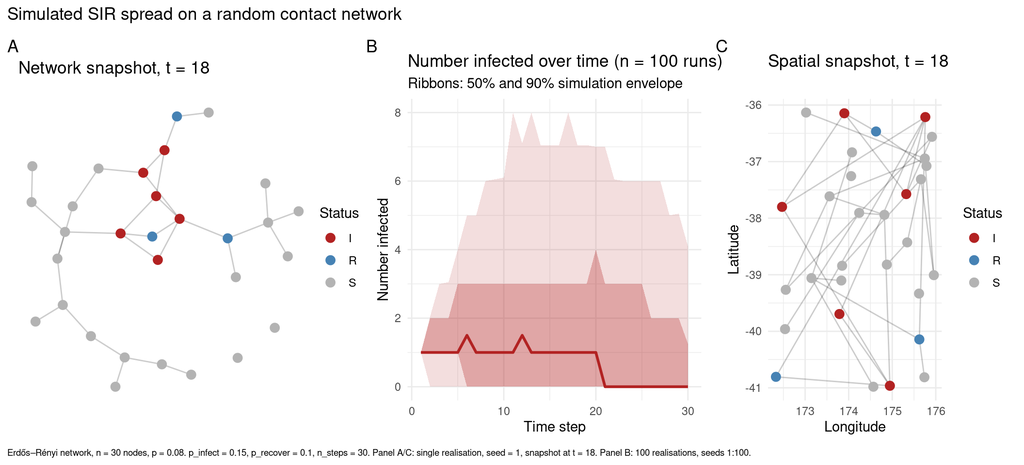

```r
capstone_fig <- (panel_A | panel_B | panel_C) +
  plot_annotation(
    title = "Simulated SIR spread on a random contact network",
    caption = paste0(
      "Erdős–Rényi network, n = ", n_nodes, " nodes, p = 0.08. ",
      "p_infect = 0.15, p_recover = 0.1, n_steps = ", n_steps, ". ",
      "Panel A/C: single realisation, seed = 1, snapshot at t = ", t_peak, ". ",
      "Panel B: ", n_sims, " realisations, seeds 1:", n_sims, "."
    ),
    tag_levels = "A"
  ) &
  theme(plot.caption = element_text(size = 7, hjust = 0))

capstone_fig
```

**Model written rationale (~250 words):**

> This figure combines three views of the same simulated outbreak, each drawing on a different week of the course. Panel A is a single network snapshot at the epidemic’s peak, using the node-link encoding and layout conventions from Week 7 (force-directed layout, colour encoding a categorical node attribute rather than a continuous one, to avoid over-encoding). Panel B is the Week 5/6 ribbon idiom (median plus 50%/90% simulation envelopes) applied here not to a simple stochastic trajectory but to the number infected across 100 network-constrained SIR runs, showing that any single run (like the one shown in Panel A) sits inside a wide range of plausible outcomes. Panel C repeats Panel A’s snapshot but with the nodes placed at (simulated) real coordinates rather than an abstract layout, applying this week’s spatial-network material and making explicit that “the network” and “the map” are two different, complementary representations of the same underlying data.

> No single panel could make all of these points together: Panel A alone risks over-interpreting one lucky/unlucky draw; Panel B alone loses the concrete sense of *which* nodes got infected and how they’re connected; Panel C alone says nothing about uncertainty. Together they show structure, uncertainty, and geography as three lenses on one process. Colour (grey/red/blue for S/I/R) and a minimal theme are held constant across panels A and C for visual consistency, and the caption records every parameter and seed needed to regenerate the figure exactly, following this course’s running reproducibility convention.

> References: Kolaczyk & Csárdi, *Statistical Analysis of Network Data with R* (network visualisation conventions, Panels A/C); Bjørnstad (2018), *Epidemics: Models and Data using R* (SIR simulation design, all panels).

This figure and write-up form the course’s capstone deliverable, integrating simulation (Week 5), uncertainty (Week 6), network visualisation (Week 7), and spatial/dynamic network visualisation (Week 8).

## Optional extension: animating the spatial spread

Panel C above is a *single frame*, i.e. one time point, frozen. It shows *where* the outbreak had reached by `t = t_peak`, but not *how* it got there: which nodes lit up early versus late, or whether the infection spread outward from one place or broke out in several places at once. That’s the same limitation Exercise 2.2 raised for network growth in Tutorial 2, and the same fix applies: animate it.

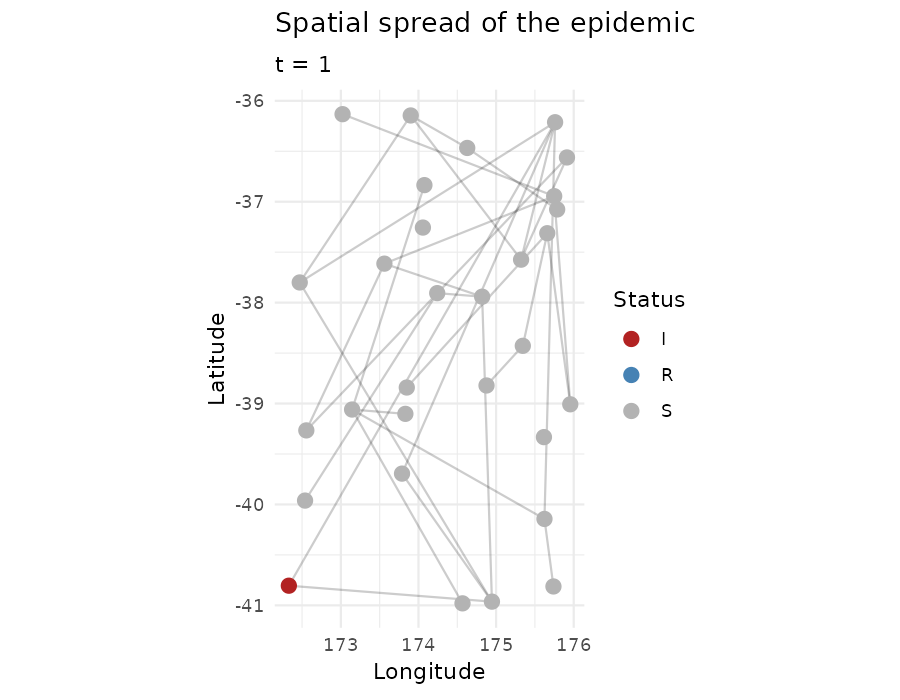

```r
# Requires: install.packages(c("gganimate", "gifski"))
library(gganimate)

# NOTE on two common rendering errors here, neither a code-logic bug:
#  1. "Error in `device()`: unable to start device 'png'" -- the default
#     png() device can't find an X11/Cairo backend, common on headless
#     servers/containers. Fixed below via device = "ragg_png" (falls
#     back to the default if the `ragg` package isn't installed); or
#     set options(bitmapType = "cairo") near the top of the document if
#     your R has Cairo but not X11.
#  2. "One or both dimensions exceed the maximum (50000px)" -- gganimate's
#     animate() defaults `units` to "in" (inches), not pixels. Passing
#     width = 900, height = 700 without units = "px" is read as
#     a 900x700-*inch* canvas (HUGE!!), which at res = 150 is >100,000px per side.
#     Always pass units = "px" explicitly when giving pixel dimensions.
anim_device <- if (requireNamespace("ragg", quietly = TRUE)) "ragg_png" else "png"

# Static pieces: node coordinates and the (fixed) edge list, both from
# the spatial snapshot built for Panel C
nodes_xy <- sim_coords
edges_xy <- as.data.frame(igraph::as_edgelist(g_sim)) |>
  setNames(c("from", "to")) |>
  left_join(nodes_xy, by = c("from" = "name")) |>
  rename(x_from = lon, y_from = lat) |>
  left_join(nodes_xy, by = c("to" = "name")) |>
  rename(x_to = lon, y_to = lat)

# Node status at every time step, long format: one row per node per frame
status_over_time <- as.data.frame(hist1) |>
  setNames(as.character(1:n_nodes)) |>
  mutate(frame = row_number()) |>
  tidyr::pivot_longer(-frame, names_to = "name", values_to = "status") |>
  left_join(nodes_xy, by = "name")

p_spatial_anim <- ggplot() +
  geom_segment(data = edges_xy,
               aes(x = x_from, y = y_from, xend = x_to, yend = y_to),
               alpha = 0.2) +
  geom_point(data = status_over_time,
             aes(lon, lat, colour = status), size = 3) +
  scale_colour_manual(values = c(S = "grey70", I = "firebrick", R = "steelblue")) +
  coord_fixed(ratio = 1.3) +
  theme_minimal() +
  labs(title = "Spatial spread of the epidemic",
       subtitle = "t = {closest_state}",
       x = "Longitude", y = "Latitude", colour = "Status") +
  transition_states(frame, transition_length = 1, state_length = 1)

animate(p_spatial_anim, nframes = n_steps * 2, fps = 5,
        width = 900, height = 700, units = "px", res = 150,
        renderer = gifski_renderer(), device = anim_device)
```

```r
anim_save("sir_spatial_spread.gif")
```

**Discussion.** As in Exercise 2.2, the animated version and the static snapshot(s) are good at different things, and neither replaces the other:

- The animation makes the *diffusion process* visible, in particular whether the outbreak spreads outward from a single seed node, jumps between distant clusters via a few long edges, or stalls and restarts. None of that is recoverable from a single frame, however well-chosen `t` is.
- A single static snapshot (Panel C) is still the right choice *inside* the capstone’s multi-panel figure: an animated GIF cannot sit next to Panels A and B in a static report or a printed document, and a reader scanning the figure once can compare A, B and C side by side in a way they cannot compare frames of a GIF.
- The two are complementary in the same way Panels A/B/C already are: use the animation for exploration and for a supplementary/appendix figure or slide, and use one representative static frame (chosen and justified as such) for the figure that has to stand on its own on a page.

As with every stochastic figure in this course, the same reproducibility record applies here: this animation is from the same `seed = 1` run as Panels A and C, uses the same node positions (`sim_coords`), and the same S/I/R colour scale. So it reads as one more view of the *same* epidemic, not a different one.